# PneumoScan - Automated Pneumonia Detection in Chest X-Rays Using Convolutional Neural Networks

**Group 9:**

- Ifediorah, Kenechukwu (9052693)
- Owulu, Amarachukwu (8923561)

**Objective:**

The objective of this project is to develop and implement a convolutional neural network (CNN) model capable of accurately detecting pneumonia from chest X-ray images, fine-tune existing pre-trained models and compare the outcomes and performances. This system aims to:

- Explore the effectiveness of various CNN architectures in medical image classification tasks
- Evaluate the model's performance using standard metrics such as accuracy, precision-recall curve, etc

This project has significant real-world applications in healthcare settings, potentially reducing diagnostic time, improving resource allocation, and enhancing patient outcomes through earlier and more accurate pneumonia detection.

**About the Dataset**

The dataset for this project is obtained from [Chest X-Ray Immages (Pneumonia)](https://www.kaggle.com/paultimothymooney/chest-xray-pneumonia)

***Note:** The dataset used in this project complies with the health-ethical rules and is suitable for use as a license.*

**Contextual Summary:**

[figure not shown]

*Figure S6. Illustrative Examples of Chest X-Rays in Patients with Pneumonia, Related to Figure 6*

The normal chest X-ray (left panel) depicts clear lungs without any areas of abnormal opacification in the image. Bacterial pneumonia (middle) typically exhibits a focal lobar consolidation, in this case in the right upper lobe (white arrows), whereas viral pneumonia (right) manifests with a more diffuse ‘‘interstitial’’ pattern in both lungs.

http://www.cell.com/cell/fulltext/S0092-8674(18)30154-530154-5)

**Content:**

The dataset is organized into 3 folders (train, test, val) and contains subfolders for each image category (Pneumonia/Normal). There are 5,863 X-Ray images (JPEG) and 2 categories (Pneumonia/Normal).

Chest X-ray images (anterior-posterior) were selected from retrospective cohorts of pediatric patients of one to five years old from Guangzhou Women and Children’s Medical Center, Guangzhou. All chest X-ray imaging was performed as part of patients’ routine clinical care.

For the analysis of chest x-ray images, all chest radiographs were initially screened for quality control by removing all low quality or unreadable scans. The diagnoses for the images were then graded by two expert physicians before being cleared. In order to account for any grading errors, the evaluation set was also checked by a third expert.

## 1. Load and Explore Data

```python
# Import necessary libraries
import numpy as np
import matplotlib.pyplot as plt
import tensorflow as tf
from tensorflow import keras
from tensorflow.keras import layers
from tensorflow.keras.models import Sequential, Model
from tensorflow.keras.layers import Conv2D, MaxPooling2D, Flatten, Dense, Dropout, GlobalAveragePooling2D
from tensorflow.keras.preprocessing.image import ImageDataGenerator
from tensorflow.keras.utils import image_dataset_from_directory
from tensorflow.keras.callbacks import ModelCheckpoint
from sklearn.metrics import classification_report, confusion_matrix
from tensorflow.keras.callbacks import EarlyStopping, ReduceLROnPlateau
from tensorflow.keras.applications.mobilenet_v2 import preprocess_input
import pathlib
import seaborn as sns
from sklearn.metrics import precision_recall_curve
from sklearn.utils import class_weight
```

```python
# Loading the data
import os
for dirname, _, filenames in os.walk('/kaggle/input'):
    for filename in filenames:
        print(os.path.join(dirname, filename))
```

[output not shown]

[output cut: 5801 more lines]

[output not shown]

```python
# Directories for the training, validation, and test splits
train_dir = pathlib.Path("../input/chest-xray-images/chest_xray/train")
val_dir = pathlib.Path("../input/chest-xray-images/chest_xray/val")
test_dir = pathlib.Path("../input/chest-xray-images/chest_xray/test")
```

```python
train_dataset = image_dataset_from_directory(
    train_dir,
    image_size=(512, 512),
    batch_size=32)
validation_dataset = image_dataset_from_directory(
    val_dir,
    image_size=(512, 512),
    batch_size=32)
test_dataset = image_dataset_from_directory(
    test_dir,
    image_size=(512, 512),
    batch_size=32)
```

```
Found 4100 files belonging to 2 classes.
Found 1171 files belonging to 2 classes.
Found 585 files belonging to 2 classes.
```

```python
for train_data_batch, train_labels_batch in train_dataset:
    print ('Training Data Shape:')
    print("data batch shape:", train_data_batch.shape)
    print("labels batch shape:", train_labels_batch.shape)
    break

for val_data_batch, val_labels_batch in validation_dataset:
    print ('\nValidation Data Shape:')
    print("data batch shape:", val_data_batch.shape)
    print("labels batch shape:", val_labels_batch.shape)
    break

for test_data_batch, test_labels_batch in test_dataset:
    print ('\nTesting Data Shape:')
    print("data batch shape:", test_data_batch.shape)
    print("labels batch shape:", test_labels_batch.shape)
    break
```

```
Training Data Shape:
data batch shape: (32, 512, 512, 3)
labels batch shape: (32,)

Validation Data Shape:
data batch shape: (32, 512, 512, 3)
labels batch shape: (32,)

Testing Data Shape:
data batch shape: (32, 512, 512, 3)
labels batch shape: (32,)
```

```python
# Examine a sample of the labels
# Get the first batch from the dataset
first_batch = next(iter(train_dataset))

# Unpack the batch into images and labels
images, labels = first_batch

# Now you can access just the labels
print(labels)
```

```
tf.Tensor([1 1 1 1 1 1 0 1 1 0 1 1 1 1 1 1 0 1 1 0 1 0 1 1 1 1 1 1 1 0 1 1], shape=(32,), dtype=int32)
```

```python
# Function to extract all labels from the dataset
def get_labels(dataset):
    all_labels = []
    for _, labels in dataset:
        all_labels.append(labels.numpy())
    return np.concatenate(all_labels)
```

```python
train_labels = get_labels(train_dataset)
val_labels = get_labels(validation_dataset)
test_labels = get_labels(test_dataset)

train, train_count = np.unique(train_labels, return_counts=True)
val, val_count = np.unique(val_labels, return_counts=True)
test, test_count = np.unique(test_labels, return_counts=True)


# Print the distribution
for label, count in zip(train, train_count):
    label = "Normal" if label == 0 else "Pneumonia"
    print(f"Train Class {label}: {count} images ({count/len(train_labels):.2%})")
for label, count in zip(val, val_count):
    label =  "Normal" if label == 0 else "Pneumonia"
    print(f"Validation Class {label}: {count} images ({count/len(val_labels):.2%})")
for label, count in zip(test, test_count):
    label =  "Normal" if label == 0 else "Pneumonia"
    print(f"Test Class {label}: {count} images ({count/len(test_labels):.2%})")
```

```
Train Class Normal: 1109 images (27.05%)
Train Class Pneumonia: 2991 images (72.95%)
Validation Class Normal: 316 images (26.99%)
Validation Class Pneumonia: 855 images (73.01%)
Test Class Normal: 158 images (27.01%)
Test Class Pneumonia: 427 images (72.99%)
```

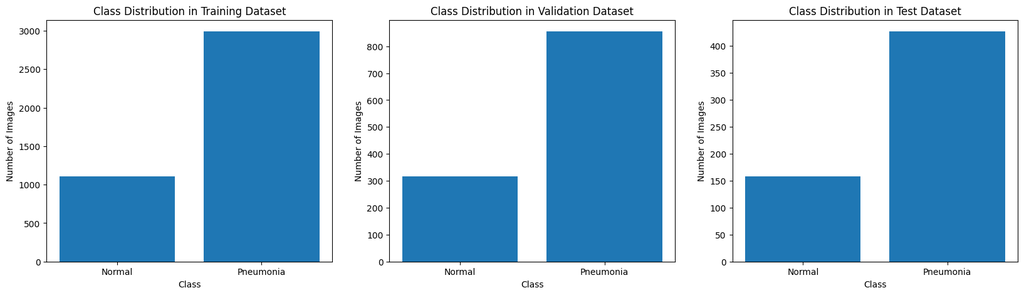

```python
def get_label_name(label):
    return 'Normal' if label == 0 else 'Pneumonia'

fig, axes = plt.subplots(1, 3, figsize=(20, 5))

axes[0].bar([get_label_name(label) for label in train], train_count)
axes[0].set_title('Class Distribution in Training Dataset')
axes[0].set_xlabel('Class')
axes[0].set_ylabel('Number of Images')

axes[1].bar([get_label_name(label) for label in val], val_count)
axes[1].set_title('Class Distribution in Validation Dataset')
axes[1].set_xlabel('Class')
axes[1].set_ylabel('Number of Images')

axes[2].bar([get_label_name(label) for label in test], test_count)
axes[2].set_title('Class Distribution in Test Dataset')
axes[2].set_xlabel('Class')
axes[2].set_ylabel('Number of Images')
plt.show();
```

We notice that there is an equal proportion of split between classes in both testing, training and validation datasets. This has been intentionally prepared this way. However, we still have class imbalance, with Normal images being just above 25% of the total dataset and Pneumonial images taking up about 75%.

**Now we'll visualize the images to see what they look like**

```python
train_data_batch.shape
```

```
TensorShape([32, 512, 512, 3])
```

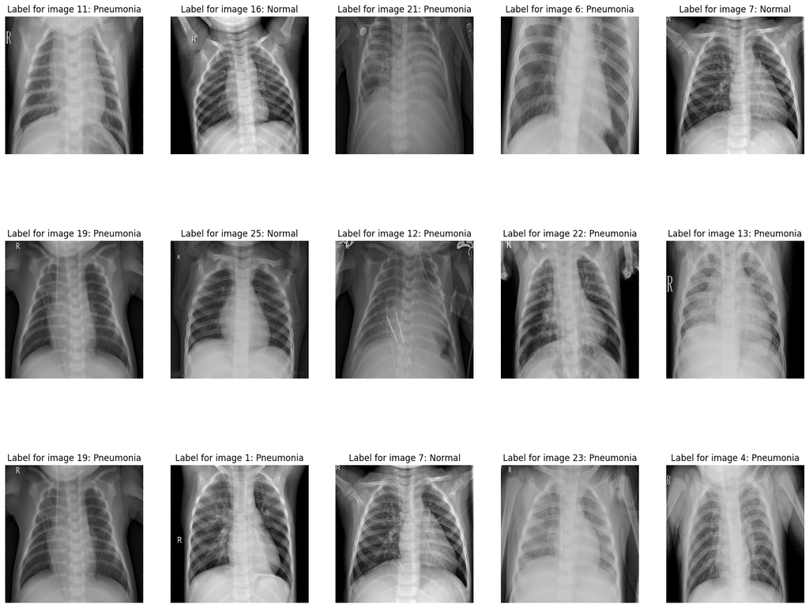

```python
fig, axes = plt.subplots(3, 5, figsize=(20, 16))
axes = axes.ravel()

for ax, i in zip(axes, np.random.choice(range(30), 20)):
    label = "Normal" if train_labels_batch[i] == 0 else "Pneumonia"
    ax.imshow(train_data_batch[i].numpy().astype("uint8"))
    ax.axis("off")
    ax.set_title(f"Label for image {i}: {label}")
```

From the human eye, only trained medical professionals would be able to identify the difference between these images. To a random person, they'll most likely look the same. We will feed the images and labels to our CNN model to learn and be able to predict.

The class imbalance is quite obvious from the random selection with the number of the pneumonia class we can see

## 2. Data Augmentation

```python
# Define the augmentation layer
data_augmentation_layer = keras.Sequential(
    [
        keras.layers.RandomRotation(0.2),
        keras.layers.RandomZoom(0.2),
        keras.layers.RandomTranslation(0.1, 0.1),
    ]
)
```

Now we'll display some augmented images to see the effects of the data augmentation layers on the input images

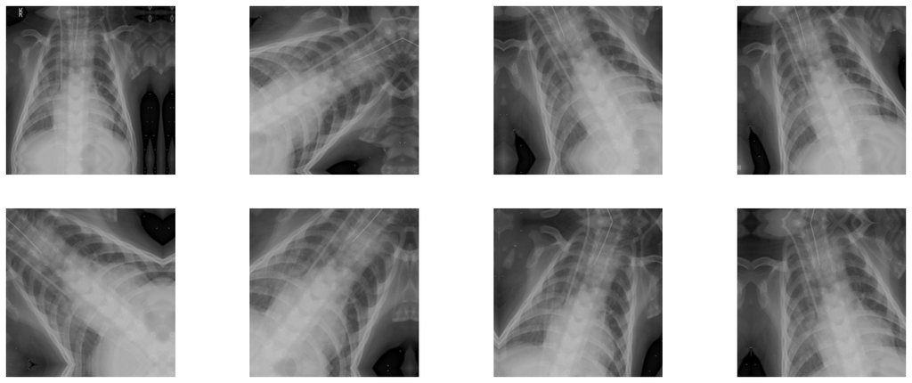

```python
plt.figure(figsize=(20, 8))
for images, _ in train_dataset.take(1):
    for i in range(8):
        augmented_images = data_augmentation_layer(images)
        ax = plt.subplot(2, 4, i + 1)
        plt.imshow(augmented_images[0].numpy().astype("uint8"))
        plt.axis("off")
```

## 3. Building the CNN Model

```python
inputs = keras.Input(shape=(512, 512, 3))
x = data_augmentation_layer(inputs)
x = layers.Rescaling(1./255)(x)
x = layers.Conv2D(filters = 32 , kernel_size = 3, padding = 'same' , activation = 'relu')(x)
x = layers.BatchNormalization()(x)
x = layers.MaxPooling2D(pool_size = 2)(x)
x = layers.Conv2D(filters = 32 , kernel_size = 3, padding = 'same' , activation = 'relu')(x)
x = layers.Dropout(0.1)(x)
x = layers.BatchNormalization()(x)
x = layers.MaxPooling2D(pool_size = 2)(x)
x = layers.Conv2D(filters = 64 , kernel_size = 3, padding = 'same' , activation = 'relu')(x)
x = layers.Dropout(0.1)(x)
x = layers.BatchNormalization()(x)
x = layers.MaxPooling2D(pool_size = 2)(x)
x = layers.Conv2D(filters = 64 , kernel_size = 3 , padding = 'same' , activation = 'relu')(x)
x = layers.Dropout(0.2)(x)
x = layers.BatchNormalization()(x)
x = layers.MaxPooling2D(pool_size = 2)(x)
x = layers.Conv2D(filters = 128 , kernel_size = 3 , padding = 'same' , activation = 'relu')(x)
x = layers.Dropout(0.2)(x)
x = layers.BatchNormalization()(x)
x = layers.MaxPooling2D(pool_size = 2)(x)
x = layers.Conv2D(filters = 128 , kernel_size = 3 , padding = 'same' , activation = 'relu')(x)
x = layers.Dropout(0.3)(x)
x = layers.BatchNormalization()(x)
x = layers.MaxPooling2D(pool_size = 2)(x)
x = layers.Conv2D(filters = 256 , kernel_size = 3 , padding = 'same' , activation = 'relu')(x)
x = layers.Flatten()(x)
x = layers.Dense(units = 128 , activation = 'relu')(x)
x = layers.Dropout(0.5)(x)
outputs = layers.Dense(units = 1 , activation = 'sigmoid')(x)
model = keras.Model(inputs, outputs)
```

```python
model.summary()
```

```
Model: "functional_1"
```

```
┏━━━━━━━━━━━━━━━━━━━━━━━━━━━━━━━━━━━━━━┳━━━━━━━━━━━━━━━━━━━━━━━━━━━━━┳━━━━━━━━━━━━━━━━━┓
┃ Layer (type)                         ┃ Output Shape                ┃         Param # ┃
┡━━━━━━━━━━━━━━━━━━━━━━━━━━━━━━━━━━━━━━╇━━━━━━━━━━━━━━━━━━━━━━━━━━━━━╇━━━━━━━━━━━━━━━━━┩
│ input_layer_1 (InputLayer)           │ (None, 512, 512, 3)         │               0 │
├──────────────────────────────────────┼─────────────────────────────┼─────────────────┤
│ sequential (Sequential)              │ (None, 512, 512, 3)         │               0 │
├──────────────────────────────────────┼─────────────────────────────┼─────────────────┤
│ rescaling (Rescaling)                │ (None, 512, 512, 3)         │               0 │
├──────────────────────────────────────┼─────────────────────────────┼─────────────────┤
│ conv2d (Conv2D)                      │ (None, 512, 512, 32)        │             896 │
├──────────────────────────────────────┼─────────────────────────────┼─────────────────┤
│ batch_normalization                  │ (None, 512, 512, 32)        │             128 │
│ (BatchNormalization)                 │                             │                 │
├──────────────────────────────────────┼─────────────────────────────┼─────────────────┤
│ max_pooling2d (MaxPooling2D)         │ (None, 256, 256, 32)        │               0 │
├──────────────────────────────────────┼─────────────────────────────┼─────────────────┤
│ conv2d_1 (Conv2D)                    │ (None, 256, 256, 32)        │           9,248 │
├──────────────────────────────────────┼─────────────────────────────┼─────────────────┤
│ dropout (Dropout)                    │ (None, 256, 256, 32)        │               0 │
├──────────────────────────────────────┼─────────────────────────────┼─────────────────┤
│ batch_normalization_1                │ (None, 256, 256, 32)        │             128 │
│ (BatchNormalization)                 │                             │                 │
├──────────────────────────────────────┼─────────────────────────────┼─────────────────┤
│ max_pooling2d_1 (MaxPooling2D)       │ (None, 128, 128, 32)        │               0 │
├──────────────────────────────────────┼─────────────────────────────┼─────────────────┤
│ conv2d_2 (Conv2D)                    │ (None, 128, 128, 64)        │          18,496 │
├──────────────────────────────────────┼─────────────────────────────┼─────────────────┤
│ dropout_1 (Dropout)                  │ (None, 128, 128, 64)        │               0 │
├──────────────────────────────────────┼─────────────────────────────┼─────────────────┤
│ batch_normalization_2                │ (None, 128, 128, 64)        │             256 │
│ (BatchNormalization)                 │                             │                 │
├──────────────────────────────────────┼─────────────────────────────┼─────────────────┤
│ max_pooling2d_2 (MaxPooling2D)       │ (None, 64, 64, 64)          │               0 │
├──────────────────────────────────────┼─────────────────────────────┼─────────────────┤
│ conv2d_3 (Conv2D)                    │ (None, 64, 64, 64)          │          36,928 │
├──────────────────────────────────────┼─────────────────────────────┼─────────────────┤
│ dropout_2 (Dropout)                  │ (None, 64, 64, 64)          │               0 │
├──────────────────────────────────────┼─────────────────────────────┼─────────────────┤
│ batch_normalization_3                │ (None, 64, 64, 64)          │             256 │
│ (BatchNormalization)                 │                             │                 │
```

[output cut: 16 more lines]

```
│ batch_normalization_5                │ (None, 16, 16, 128)         │             512 │
│ (BatchNormalization)                 │                             │                 │
├──────────────────────────────────────┼─────────────────────────────┼─────────────────┤
│ max_pooling2d_5 (MaxPooling2D)       │ (None, 8, 8, 128)           │               0 │
├──────────────────────────────────────┼─────────────────────────────┼─────────────────┤
│ conv2d_6 (Conv2D)                    │ (None, 8, 8, 256)           │         295,168 │
├──────────────────────────────────────┼─────────────────────────────┼─────────────────┤
│ flatten (Flatten)                    │ (None, 16384)               │               0 │
├──────────────────────────────────────┼─────────────────────────────┼─────────────────┤
│ dense (Dense)                        │ (None, 128)                 │       2,097,280 │
├──────────────────────────────────────┼─────────────────────────────┼─────────────────┤
│ dropout_5 (Dropout)                  │ (None, 128)                 │               0 │
├──────────────────────────────────────┼─────────────────────────────┼─────────────────┤
│ dense_1 (Dense)                      │ (None, 1)                   │             129 │
└──────────────────────────────────────┴─────────────────────────────┴─────────────────┘
```

```
 Total params: 2,681,377 (10.23 MB)
```

```
 Trainable params: 2,680,481 (10.23 MB)
```

```
 Non-trainable params: 896 (3.50 KB)
```

We are going to train the model with different optimizers to determine which works better

```python
print("Num GPUs Available: ", len(tf.config.list_physical_devices('GPU')))
print("GPU Name:", tf.test.gpu_device_name())
```

```
Num GPUs Available:  2
GPU Name: /device:GPU:0
```

```
I0000 00:00:1744460288.184556      31 gpu_device.cc:2022] Created device /device:GPU:0 with 13942 MB memory:  -> device: 0, name: Tesla T4, pci bus id: 0000:00:04.0, compute capability: 7.5
I0000 00:00:1744460288.184767      31 gpu_device.cc:2022] Created device /device:GPU:1 with 13942 MB memory:  -> device: 1, name: Tesla T4, pci bus id: 0000:00:05.0, compute capability: 7.5
```

```python
model.compile(
    loss="binary_crossentropy",
    optimizer="adam",
    metrics=["accuracy"]
)

callbacks = [
    keras.callbacks.ModelCheckpoint(
        filepath="/kaggle/working/best_cnn_adam.keras",
        save_best_only=True,
        monitor="val_loss"
    ),

    # Early stopping to prevent overfitting
    EarlyStopping(
        monitor='val_loss',
        patience=10,               # Stop if no improvement for 10 epochs
        restore_best_weights=True  # Restore model to the best epoch
    ),

    # Learning rate reduction when plateauing
    ReduceLROnPlateau(
        monitor='val_loss',
        factor=0.5,                # Reduce LR by half
        patience=3,                # Wait 5 epochs before reducing
        min_lr=1e-6                # Don't go below this LR
    )
]

history = model.fit(
    train_dataset,
    epochs=50,
    validation_data=validation_dataset,
    callbacks=callbacks
)
```

```
E0000 00:00:1744460374.715503      31 meta_optimizer.cc:966] layout failed: INVALID_ARGUMENT: Size of values 0 does not match size of permutation 4 @ fanin shape inStatefulPartitionedCall/functional_1_1/dropout_1/stateless_dropout/SelectV2-2-TransposeNHWCToNCHW-LayoutOptimizer
I0000 00:00:1744460376.189667      72 cuda_dnn.cc:529] Loaded cuDNN version 90300
```

```
129/129 ━━━━━━━━━━━━━━━━━━━━ 101s 671ms/step - accuracy: 0.8020 - loss: 0.6997 - val_accuracy: 0.7301 - val_loss: 10.0044 - learning_rate: 0.0010
129/129 ━━━━━━━━━━━━━━━━━━━━ 87s 675ms/step - accuracy: 0.8854 - loss: 0.2785 - val_accuracy: 0.7301 - val_loss: 10.1983 - learning_rate: 0.0010
129/129 ━━━━━━━━━━━━━━━━━━━━ 87s 673ms/step - accuracy: 0.8944 - loss: 0.2617 - val_accuracy: 0.7301 - val_loss: 3.1047 - learning_rate: 0.0010
129/129 ━━━━━━━━━━━━━━━━━━━━ 86s 664ms/step - accuracy: 0.9136 - loss: 0.2236 - val_accuracy: 0.7378 - val_loss: 1.4897 - learning_rate: 0.0010
129/129 ━━━━━━━━━━━━━━━━━━━━ 85s 661ms/step - accuracy: 0.9090 - loss: 0.2414 - val_accuracy: 0.7301 - val_loss: 2.4924 - learning_rate: 0.0010
129/129 ━━━━━━━━━━━━━━━━━━━━ 85s 659ms/step - accuracy: 0.9222 - loss: 0.2002 - val_accuracy: 0.9180 - val_loss: 0.2166 - learning_rate: 0.0010
129/129 ━━━━━━━━━━━━━━━━━━━━ 85s 657ms/step - accuracy: 0.9320 - loss: 0.1986 - val_accuracy: 0.9061 - val_loss: 0.2323 - learning_rate: 0.0010
129/129 ━━━━━━━━━━━━━━━━━━━━ 85s 657ms/step - accuracy: 0.9233 - loss: 0.2174 - val_accuracy: 0.7353 - val_loss: 1.9465 - learning_rate: 0.0010
129/129 ━━━━━━━━━━━━━━━━━━━━ 84s 650ms/step - accuracy: 0.9336 - loss: 0.1830 - val_accuracy: 0.7558 - val_loss: 0.8931 - learning_rate: 0.0010
129/129 ━━━━━━━━━━━━━━━━━━━━ 84s 652ms/step - accuracy: 0.9373 - loss: 0.1583 - val_accuracy: 0.8369 - val_loss: 0.6640 - learning_rate: 5.0000e-04
129/129 ━━━━━━━━━━━━━━━━━━━━ 85s 657ms/step - accuracy: 0.9545 - loss: 0.1360 - val_accuracy: 0.8557 - val_loss: 0.4485 - learning_rate: 5.0000e-04
129/129 ━━━━━━━━━━━━━━━━━━━━ 84s 653ms/step - accuracy: 0.9483 - loss: 0.1450 - val_accuracy: 0.7720 - val_loss: 1.0940 - learning_rate: 5.0000e-04
129/129 ━━━━━━━━━━━━━━━━━━━━ 84s 652ms/step - accuracy: 0.9520 - loss: 0.1319 - val_accuracy: 0.8096 - val_loss: 0.7684 - learning_rate: 2.5000e-04
129/129 ━━━━━━━━━━━━━━━━━━━━ 85s 657ms/step - accuracy: 0.9512 - loss: 0.1285 - val_accuracy: 0.8822 - val_loss: 0.3049 - learning_rate: 2.5000e-04
129/129 ━━━━━━━━━━━━━━━━━━━━ 85s 656ms/step - accuracy: 0.9627 - loss: 0.1059 - val_accuracy: 0.8898 - val_loss: 0.2710 - learning_rate: 2.5000e-04
129/129 ━━━━━━━━━━━━━━━━━━━━ 85s 657ms/step - accuracy: 0.9639 - loss: 0.1089 - val_accuracy: 0.8856 - val_loss: 0.2760 - learning_rate: 1.2500e-04
```

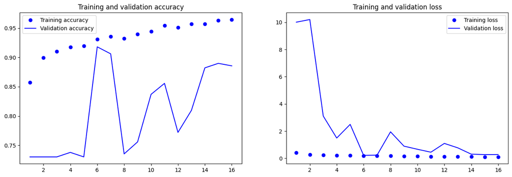

```python
train_accuracy = history.history["accuracy"]
val_accuracy = history.history["val_accuracy"]
train_loss = history.history["loss"]
val_loss = history.history["val_loss"]

fig, axes = plt.subplots(1, 2, figsize=(16, 5))
axes = axes.ravel()

epochs = range(1, len(train_accuracy) + 1)
axes[0].plot(epochs, train_accuracy, "bo", label="Training accuracy")
axes[0].plot(epochs, val_accuracy, "b", label="Validation accuracy")
axes[0].set_title("Training and validation accuracy")
axes[0].legend()
axes[1].plot(epochs, train_loss, "bo", label="Training loss")
axes[1].plot(epochs, val_loss, "b", label="Validation loss")
axes[1].set_title("Training and validation loss")
axes[1].legend()
plt.show()
```

Best validation loss and validation accuracy was achieved on epoch 6.

- Validation Loss: 0.2166
- Validation Accuracy: 0.9180

```python
# Load the best models (the best ones saved during training)
model.load_weights("/kaggle/working/best_cnn_adam.keras")
```

```python
cnn_adam_model_loss, cnn_adam_model_acc = model.evaluate(test_dataset)

print(f"CNN Accuracy (Adam): {cnn_adam_model_acc}")
```

```
19/19 ━━━━━━━━━━━━━━━━━━━━ 3s 131ms/step - accuracy: 0.8713 - loss: 0.5820
CNN Accuracy (Adam): 0.8529914617538452
```

```python
# --- Convert test dataset to NumPy arrays ---
test_images_list = []
test_labels_list = []

for images, labels in test_dataset:
    test_images_list.append(images.numpy())
    test_labels_list.append(labels.numpy())

test_images = np.concatenate(test_images_list)
test_labels = np.concatenate(test_labels_list)
```

```
19/19 ━━━━━━━━━━━━━━━━━━━━ 3s 122ms/step
CNN Classification Report with Adam Optimizer:
              precision    recall  f1-score   support

           0       0.93      0.49      0.64       158
           1       0.84      0.99      0.91       427

    accuracy                           0.85       585
   macro avg       0.88      0.74      0.78       585
weighted avg       0.86      0.85      0.84       585
```

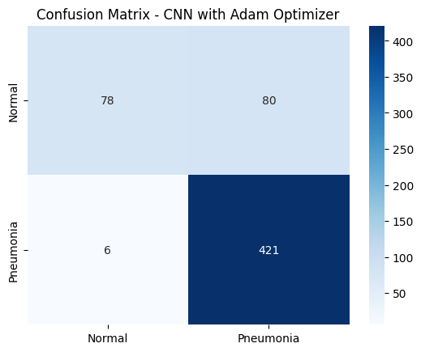

```python
y_pred_cnn_adam = model.predict(test_images)
y_pred_cnn_adam = (y_pred_cnn_adam > 0.5).astype("int32")

cnn_adam_cm = confusion_matrix(test_labels, y_pred_cnn_adam)
print("CNN Classification Report with Adam Optimizer:")
print(classification_report(test_labels, y_pred_cnn_adam))

# Plot confusion matrix
sns.heatmap(cnn_adam_cm, annot=True, fmt="d", cmap='Blues', xticklabels=['Normal', 'Pneumonia'], yticklabels=['Normal', 'Pneumonia'])
plt.title("Confusion Matrix - CNN with Adam Optimizer")
plt.show()
```

We'll try with the rmsprop optimizer to see if we get a better model

```python
model.compile(
    loss="binary_crossentropy",
    optimizer="rmsprop",
    metrics=["accuracy"]
)

callbacks = [
    keras.callbacks.ModelCheckpoint(
        filepath="/kaggle/working/best_cnn_rms.keras",
        save_best_only=True,
        monitor="val_loss"
    ),

    # Early stopping to prevent overfitting
    EarlyStopping(
        monitor='val_loss',
        patience=10,               # Stop if no improvement for 10 epochs
        restore_best_weights=True  # Restore model to the best epoch
    ),

    # Learning rate reduction when plateauing
    ReduceLROnPlateau(
        monitor='val_loss',
        factor=0.5,                # Reduce LR by half
        patience=3,                # Wait 5 epochs before reducing
        min_lr=1e-6                # Don't go below this LR
    )
]

history = model.fit(
    train_dataset,
    epochs=50,
    validation_data=validation_dataset,
    callbacks=callbacks
)
```

```
E0000 00:00:1744463052.559105      31 meta_optimizer.cc:966] layout failed: INVALID_ARGUMENT: Size of values 0 does not match size of permutation 4 @ fanin shape inStatefulPartitionedCall/functional_1_1/dropout_1/stateless_dropout/SelectV2-2-TransposeNHWCToNCHW-LayoutOptimizer
```

```
129/129 ━━━━━━━━━━━━━━━━━━━━ 92s 669ms/step - accuracy: 0.9123 - loss: 0.2557 - val_accuracy: 0.8053 - val_loss: 0.6676 - learning_rate: 0.0010
129/129 ━━━━━━━━━━━━━━━━━━━━ 85s 661ms/step - accuracy: 0.9183 - loss: 0.2224 - val_accuracy: 0.8958 - val_loss: 0.2651 - learning_rate: 0.0010
129/129 ━━━━━━━━━━━━━━━━━━━━ 85s 660ms/step - accuracy: 0.9208 - loss: 0.2080 - val_accuracy: 0.8096 - val_loss: 0.8484 - learning_rate: 0.0010
129/129 ━━━━━━━━━━━━━━━━━━━━ 85s 657ms/step - accuracy: 0.9345 - loss: 0.2014 - val_accuracy: 0.8326 - val_loss: 0.5764 - learning_rate: 0.0010
129/129 ━━━━━━━━━━━━━━━━━━━━ 85s 659ms/step - accuracy: 0.9297 - loss: 0.1946 - val_accuracy: 0.8249 - val_loss: 0.7699 - learning_rate: 0.0010
129/129 ━━━━━━━━━━━━━━━━━━━━ 85s 658ms/step - accuracy: 0.9449 - loss: 0.1789 - val_accuracy: 0.8847 - val_loss: 0.3544 - learning_rate: 5.0000e-04
129/129 ━━━━━━━━━━━━━━━━━━━━ 85s 659ms/step - accuracy: 0.9507 - loss: 0.1565 - val_accuracy: 0.9206 - val_loss: 0.2835 - learning_rate: 5.0000e-04
129/129 ━━━━━━━━━━━━━━━━━━━━ 85s 659ms/step - accuracy: 0.9534 - loss: 0.1337 - val_accuracy: 0.9197 - val_loss: 0.2656 - learning_rate: 5.0000e-04
129/129 ━━━━━━━━━━━━━━━━━━━━ 85s 660ms/step - accuracy: 0.9515 - loss: 0.1384 - val_accuracy: 0.8232 - val_loss: 1.0087 - learning_rate: 2.5000e-04
129/129 ━━━━━━━━━━━━━━━━━━━━ 85s 660ms/step - accuracy: 0.9562 - loss: 0.1193 - val_accuracy: 0.7677 - val_loss: 2.0067 - learning_rate: 2.5000e-04
129/129 ━━━━━━━━━━━━━━━━━━━━ 85s 657ms/step - accuracy: 0.9671 - loss: 0.1024 - val_accuracy: 0.9001 - val_loss: 0.3381 - learning_rate: 2.5000e-04
129/129 ━━━━━━━━━━━━━━━━━━━━ 85s 660ms/step - accuracy: 0.9605 - loss: 0.1151 - val_accuracy: 0.9471 - val_loss: 0.1861 - learning_rate: 1.2500e-04
129/129 ━━━━━━━━━━━━━━━━━━━━ 85s 660ms/step - accuracy: 0.9659 - loss: 0.1019 - val_accuracy: 0.9291 - val_loss: 0.2430 - learning_rate: 1.2500e-04
129/129 ━━━━━━━━━━━━━━━━━━━━ 86s 664ms/step - accuracy: 0.9601 - loss: 0.1190 - val_accuracy: 0.9496 - val_loss: 0.1683 - learning_rate: 1.2500e-04
129/129 ━━━━━━━━━━━━━━━━━━━━ 85s 658ms/step - accuracy: 0.9626 - loss: 0.1096 - val_accuracy: 0.9479 - val_loss: 0.1818 - learning_rate: 1.2500e-04
129/129 ━━━━━━━━━━━━━━━━━━━━ 86s 663ms/step - accuracy: 0.9657 - loss: 0.1044 - val_accuracy: 0.9325 - val_loss: 0.2677 - learning_rate: 1.2500e-04
129/129 ━━━━━━━━━━━━━━━━━━━━ 85s 659ms/step - accuracy: 0.9633 - loss: 0.1016 - val_accuracy: 0.9368 - val_loss: 0.2219 - learning_rate: 1.2500e-04
129/129 ━━━━━━━━━━━━━━━━━━━━ 85s 657ms/step - accuracy: 0.9668 - loss: 0.0909 - val_accuracy: 0.9471 - val_loss: 0.1953 - learning_rate: 6.2500e-05
129/129 ━━━━━━━━━━━━━━━━━━━━ 85s 661ms/step - accuracy: 0.9692 - loss: 0.0894 - val_accuracy: 0.9471 - val_loss: 0.2008 - learning_rate: 6.2500e-05
129/129 ━━━━━━━━━━━━━━━━━━━━ 85s 659ms/step - accuracy: 0.9691 - loss: 0.0829 - val_accuracy: 0.9471 - val_loss: 0.1854 - learning_rate: 6.2500e-05
129/129 ━━━━━━━━━━━━━━━━━━━━ 85s 661ms/step - accuracy: 0.9715 - loss: 0.0859 - val_accuracy: 0.9394 - val_loss: 0.2146 - learning_rate: 3.1250e-05
129/129 ━━━━━━━━━━━━━━━━━━━━ 85s 659ms/step - accuracy: 0.9708 - loss: 0.0789 - val_accuracy: 0.9436 - val_loss: 0.1908 - learning_rate: 3.1250e-05
129/129 ━━━━━━━━━━━━━━━━━━━━ 85s 657ms/step - accuracy: 0.9684 - loss: 0.0827 - val_accuracy: 0.9428 - val_loss: 0.1954 - learning_rate: 3.1250e-05
129/129 ━━━━━━━━━━━━━━━━━━━━ 85s 661ms/step - accuracy: 0.9706 - loss: 0.0863 - val_accuracy: 0.9462 - val_loss: 0.1857 - learning_rate: 1.5625e-05
```

Best validation loss and validation accuracy was achieved on epoch 14.

- Validation Loss: 0.1683
- Validation Accuracy: 0.9496

```python
# Load the best models (the best ones saved during training)
model.load_weights("/kaggle/working/best_cnn_rms.keras")
```

```python
cnn_rms_model_loss, cnn_rms_model_acc = model.evaluate(test_dataset)

print(f"CNN Accuracy (RMSProp): {cnn_rms_model_acc}")
```

```
19/19 ━━━━━━━━━━━━━━━━━━━━ 2s 115ms/step - accuracy: 0.9118 - loss: 0.3685
CNN Accuracy (RMSProp): 0.8991453051567078
```

```
19/19 ━━━━━━━━━━━━━━━━━━━━ 2s 116ms/step
CNN Classification Report with RMSProp Optimizer:
              precision    recall  f1-score   support

           0       0.94      0.67      0.78       158
           1       0.89      0.98      0.93       427

    accuracy                           0.90       585
   macro avg       0.91      0.83      0.86       585
weighted avg       0.90      0.90      0.89       585
```

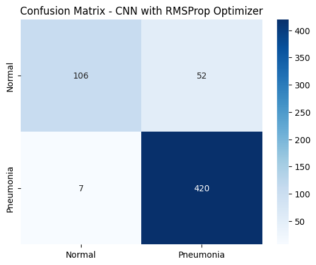

```python
y_pred_cnn_rms = model.predict(test_images)
y_pred_cnn_rms = (y_pred_cnn_rms > 0.5).astype("int32")

cnn_rms_cm = confusion_matrix(test_labels, y_pred_cnn_rms)
print("CNN Classification Report with RMSProp Optimizer:")
print(classification_report(test_labels, y_pred_cnn_rms))

# Plot confusion matrix
sns.heatmap(cnn_rms_cm, annot=True, fmt="d", cmap='Blues', xticklabels=['Normal', 'Pneumonia'], yticklabels=['Normal', 'Pneumonia'])
plt.title("Confusion Matrix - CNN with RMSProp Optimizer")
plt.show()
```

```
19/19 ━━━━━━━━━━━━━━━━━━━━ 2s 116ms/step
```

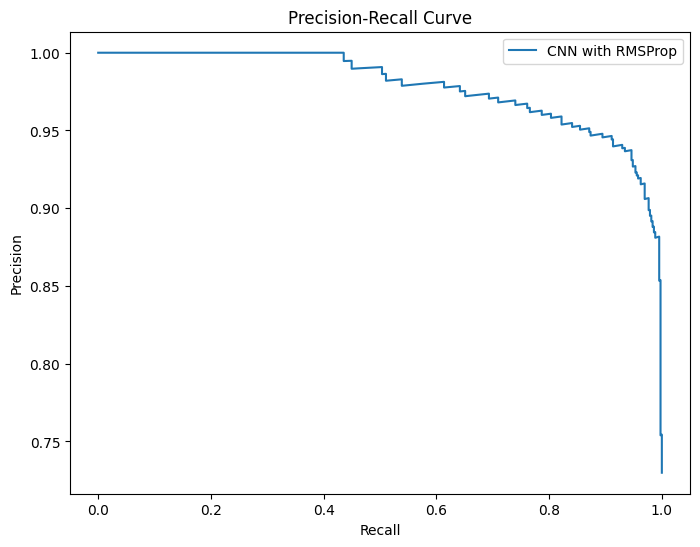

```python
precision_cnn_rms, recall_cnn_rms, _ = precision_recall_curve(test_labels, model.predict(test_images))

plt.figure(figsize=(8,6))
plt.plot(recall_cnn_rms, precision_cnn_rms, label='CNN with RMSProp')
plt.xlabel('Recall')
plt.ylabel('Precision')
plt.title('Precision-Recall Curve')
plt.legend()
plt.show()
```

We got a slightly better model using RMSProp optimizer with testing accuracy of 0.90

## 4. Fine-Tuning MobileNet

Now, we'll train fine tune a pre-trained model and see if it performs better.

```python
from tensorflow.keras.applications import MobileNetV2
```

```python
# Loading the MobileNet model
mobilenet_base =  MobileNetV2(
    weights="imagenet",
    include_top=False,
    input_shape=(512, 512, 3))

mobilenet_base.trainable = False
```

```
Downloading data from https://storage.googleapis.com/tensorflow/keras-applications/mobilenet_v2/mobilenet_v2_weights_tf_dim_ordering_tf_kernels_1.0_224_no_top.h5
9406464/9406464 ━━━━━━━━━━━━━━━━━━━━ 0s 0us/step
```

```python
mobilenet_base.summary()
```

```
Model: "mobilenetv2_1.00_224"
```

```
┏━━━━━━━━━━━━━━━━━━━━━━━━━━━┳━━━━━━━━━━━━━━━━━━━━━━━━┳━━━━━━━━━━━━━━━━┳━━━━━━━━━━━━━━━━━━━━━━━━┓
┃ Layer (type)              ┃ Output Shape           ┃        Param # ┃ Connected to           ┃
┡━━━━━━━━━━━━━━━━━━━━━━━━━━━╇━━━━━━━━━━━━━━━━━━━━━━━━╇━━━━━━━━━━━━━━━━╇━━━━━━━━━━━━━━━━━━━━━━━━┩
│ input_layer (InputLayer)  │ (None, 512, 512, 3)    │              0 │ -                      │
├───────────────────────────┼────────────────────────┼────────────────┼────────────────────────┤
│ Conv1 (Conv2D)            │ (None, 256, 256, 32)   │            864 │ input_layer[0][0]      │
├───────────────────────────┼────────────────────────┼────────────────┼────────────────────────┤
│ bn_Conv1                  │ (None, 256, 256, 32)   │            128 │ Conv1[0][0]            │
│ (BatchNormalization)      │                        │                │                        │
├───────────────────────────┼────────────────────────┼────────────────┼────────────────────────┤
│ Conv1_relu (ReLU)         │ (None, 256, 256, 32)   │              0 │ bn_Conv1[0][0]         │
├───────────────────────────┼────────────────────────┼────────────────┼────────────────────────┤
│ expanded_conv_depthwise   │ (None, 256, 256, 32)   │            288 │ Conv1_relu[0][0]       │
│ (DepthwiseConv2D)         │                        │                │                        │
├───────────────────────────┼────────────────────────┼────────────────┼────────────────────────┤
│ expanded_conv_depthwise_… │ (None, 256, 256, 32)   │            128 │ expanded_conv_depthwi… │
│ (BatchNormalization)      │                        │                │                        │
├───────────────────────────┼────────────────────────┼────────────────┼────────────────────────┤
│ expanded_conv_depthwise_… │ (None, 256, 256, 32)   │              0 │ expanded_conv_depthwi… │
│ (ReLU)                    │                        │                │                        │
├───────────────────────────┼────────────────────────┼────────────────┼────────────────────────┤
│ expanded_conv_project     │ (None, 256, 256, 16)   │            512 │ expanded_conv_depthwi… │
│ (Conv2D)                  │                        │                │                        │
├───────────────────────────┼────────────────────────┼────────────────┼────────────────────────┤
│ expanded_conv_project_BN  │ (None, 256, 256, 16)   │             64 │ expanded_conv_project… │
│ (BatchNormalization)      │                        │                │                        │
├───────────────────────────┼────────────────────────┼────────────────┼────────────────────────┤
│ block_1_expand (Conv2D)   │ (None, 256, 256, 96)   │          1,536 │ expanded_conv_project… │
├───────────────────────────┼────────────────────────┼────────────────┼────────────────────────┤
│ block_1_expand_BN         │ (None, 256, 256, 96)   │            384 │ block_1_expand[0][0]   │
│ (BatchNormalization)      │                        │                │                        │
├───────────────────────────┼────────────────────────┼────────────────┼────────────────────────┤
│ block_1_expand_relu       │ (None, 256, 256, 96)   │              0 │ block_1_expand_BN[0][… │
│ (ReLU)                    │                        │                │                        │
├───────────────────────────┼────────────────────────┼────────────────┼────────────────────────┤
│ block_1_pad               │ (None, 257, 257, 96)   │              0 │ block_1_expand_relu[0… │
│ (ZeroPadding2D)           │                        │                │                        │
├───────────────────────────┼────────────────────────┼────────────────┼────────────────────────┤
│ block_1_depthwise         │ (None, 128, 128, 96)   │            864 │ block_1_pad[0][0]      │
│ (DepthwiseConv2D)         │                        │                │                        │
```

[output cut: 373 more lines]

```
│ block_16_depthwise_relu   │ (None, 16, 16, 960)    │              0 │ block_16_depthwise_BN… │
│ (ReLU)                    │                        │                │                        │
├───────────────────────────┼────────────────────────┼────────────────┼────────────────────────┤
│ block_16_project (Conv2D) │ (None, 16, 16, 320)    │        307,200 │ block_16_depthwise_re… │
├───────────────────────────┼────────────────────────┼────────────────┼────────────────────────┤
│ block_16_project_BN       │ (None, 16, 16, 320)    │          1,280 │ block_16_project[0][0] │
│ (BatchNormalization)      │                        │                │                        │
├───────────────────────────┼────────────────────────┼────────────────┼────────────────────────┤
│ Conv_1 (Conv2D)           │ (None, 16, 16, 1280)   │        409,600 │ block_16_project_BN[0… │
├───────────────────────────┼────────────────────────┼────────────────┼────────────────────────┤
│ Conv_1_bn                 │ (None, 16, 16, 1280)   │          5,120 │ Conv_1[0][0]           │
│ (BatchNormalization)      │                        │                │                        │
├───────────────────────────┼────────────────────────┼────────────────┼────────────────────────┤
│ out_relu (ReLU)           │ (None, 16, 16, 1280)   │              0 │ Conv_1_bn[0][0]        │
└───────────────────────────┴────────────────────────┴────────────────┴────────────────────────┘
```

```
 Total params: 2,257,984 (8.61 MB)
```

```
 Trainable params: 0 (0.00 B)
```

```
 Non-trainable params: 2,257,984 (8.61 MB)
```

```python
inputs = keras.Input(shape=(512, 512, 3))
x = data_augmentation_layer(inputs)
x = layers.Rescaling(1./255)(x)
x = mobilenet_base(x)
x = layers.GlobalAveragePooling2D()(x)
x = layers.Dropout(0.2)(x)
x = layers.Dense(units = 128 , activation = 'sigmoid')(x)
outputs = layers.Dense(units = 1 , activation = 'sigmoid')(x)
mobilenet_model = keras.Model(inputs, outputs)
```

```python
mobilenet_model.summary()
```

```
Model: "functional_1"
```

```
┏━━━━━━━━━━━━━━━━━━━━━━━━━━━━━━━━━━━━━━┳━━━━━━━━━━━━━━━━━━━━━━━━━━━━━┳━━━━━━━━━━━━━━━━━┓
┃ Layer (type)                         ┃ Output Shape                ┃         Param # ┃
┡━━━━━━━━━━━━━━━━━━━━━━━━━━━━━━━━━━━━━━╇━━━━━━━━━━━━━━━━━━━━━━━━━━━━━╇━━━━━━━━━━━━━━━━━┩
│ input_layer_1 (InputLayer)           │ (None, 512, 512, 3)         │               0 │
├──────────────────────────────────────┼─────────────────────────────┼─────────────────┤
│ sequential (Sequential)              │ (None, 512, 512, 3)         │               0 │
├──────────────────────────────────────┼─────────────────────────────┼─────────────────┤
│ rescaling (Rescaling)                │ (None, 512, 512, 3)         │               0 │
├──────────────────────────────────────┼─────────────────────────────┼─────────────────┤
│ mobilenetv2_1.00_224 (Functional)    │ (None, 16, 16, 1280)        │       2,257,984 │
├──────────────────────────────────────┼─────────────────────────────┼─────────────────┤
│ global_average_pooling2d             │ (None, 1280)                │               0 │
│ (GlobalAveragePooling2D)             │                             │                 │
├──────────────────────────────────────┼─────────────────────────────┼─────────────────┤
│ dropout (Dropout)                    │ (None, 1280)                │               0 │
├──────────────────────────────────────┼─────────────────────────────┼─────────────────┤
│ dense (Dense)                        │ (None, 128)                 │         163,968 │
├──────────────────────────────────────┼─────────────────────────────┼─────────────────┤
│ dense_1 (Dense)                      │ (None, 1)                   │             129 │
└──────────────────────────────────────┴─────────────────────────────┴─────────────────┘
```

```
 Total params: 2,422,081 (9.24 MB)
```

```
 Trainable params: 164,097 (641.00 KB)
```

```
 Non-trainable params: 2,257,984 (8.61 MB)
```

```python
mobilenet_model.compile(
    loss="binary_crossentropy",
    optimizer="rmsprop",
    metrics=["accuracy"]
)

callbacks = [
    keras.callbacks.ModelCheckpoint(
        filepath="/kaggle/working/best_mnet_rms.keras",
        save_best_only=True,
        monitor="val_loss"
    ),

    # Early stopping to prevent overfitting
    EarlyStopping(
        monitor='val_loss',
        patience=10,               # Stop if no improvement for 10 epochs
        restore_best_weights=True  # Restore model to the best epoch
    ),

    # Learning rate reduction when plateauing
    ReduceLROnPlateau(
        monitor='val_loss',
        factor=0.5,                # Reduce LR by half
        patience=3,                # Wait 5 epochs before reducing
        min_lr=1e-6                # Don't go below this LR
    )
]

history = mobilenet_model.fit(
    train_dataset,
    epochs=50,
    validation_data=validation_dataset,
    callbacks=callbacks
)
```

```
I0000 00:00:1744572164.636621      69 cuda_dnn.cc:529] Loaded cuDNN version 90300
```

```
129/129 ━━━━━━━━━━━━━━━━━━━━ 55s 341ms/step - accuracy: 0.8070 - loss: 0.4215 - val_accuracy: 0.8659 - val_loss: 0.3031 - learning_rate: 0.0010
129/129 ━━━━━━━━━━━━━━━━━━━━ 42s 327ms/step - accuracy: 0.9078 - loss: 0.2220 - val_accuracy: 0.8625 - val_loss: 0.3083 - learning_rate: 0.0010
129/129 ━━━━━━━━━━━━━━━━━━━━ 44s 342ms/step - accuracy: 0.9096 - loss: 0.2046 - val_accuracy: 0.8685 - val_loss: 0.2852 - learning_rate: 0.0010
129/129 ━━━━━━━━━━━━━━━━━━━━ 43s 334ms/step - accuracy: 0.9237 - loss: 0.1894 - val_accuracy: 0.8634 - val_loss: 0.3318 - learning_rate: 0.0010
129/129 ━━━━━━━━━━━━━━━━━━━━ 44s 337ms/step - accuracy: 0.9268 - loss: 0.1827 - val_accuracy: 0.8898 - val_loss: 0.2604 - learning_rate: 0.0010
129/129 ━━━━━━━━━━━━━━━━━━━━ 44s 337ms/step - accuracy: 0.9360 - loss: 0.1752 - val_accuracy: 0.8941 - val_loss: 0.2435 - learning_rate: 0.0010
129/129 ━━━━━━━━━━━━━━━━━━━━ 43s 334ms/step - accuracy: 0.9361 - loss: 0.1665 - val_accuracy: 0.8514 - val_loss: 0.3626 - learning_rate: 0.0010
129/129 ━━━━━━━━━━━━━━━━━━━━ 44s 337ms/step - accuracy: 0.9376 - loss: 0.1650 - val_accuracy: 0.9095 - val_loss: 0.2156 - learning_rate: 0.0010
129/129 ━━━━━━━━━━━━━━━━━━━━ 43s 334ms/step - accuracy: 0.9372 - loss: 0.1661 - val_accuracy: 0.8958 - val_loss: 0.2451 - learning_rate: 0.0010
129/129 ━━━━━━━━━━━━━━━━━━━━ 43s 334ms/step - accuracy: 0.9391 - loss: 0.1549 - val_accuracy: 0.8053 - val_loss: 0.5100 - learning_rate: 0.0010
129/129 ━━━━━━━━━━━━━━━━━━━━ 43s 334ms/step - accuracy: 0.9407 - loss: 0.1635 - val_accuracy: 0.9035 - val_loss: 0.2372 - learning_rate: 0.0010
129/129 ━━━━━━━━━━━━━━━━━━━━ 43s 334ms/step - accuracy: 0.9527 - loss: 0.1399 - val_accuracy: 0.8804 - val_loss: 0.2966 - learning_rate: 5.0000e-04
129/129 ━━━━━━━━━━━━━━━━━━━━ 43s 334ms/step - accuracy: 0.9395 - loss: 0.1583 - val_accuracy: 0.8907 - val_loss: 0.2742 - learning_rate: 5.0000e-04
129/129 ━━━━━━━━━━━━━━━━━━━━ 43s 334ms/step - accuracy: 0.9393 - loss: 0.1534 - val_accuracy: 0.8924 - val_loss: 0.2684 - learning_rate: 5.0000e-04
129/129 ━━━━━━━━━━━━━━━━━━━━ 43s 337ms/step - accuracy: 0.9398 - loss: 0.1505 - val_accuracy: 0.9103 - val_loss: 0.2141 - learning_rate: 2.5000e-04
129/129 ━━━━━━━━━━━━━━━━━━━━ 43s 334ms/step - accuracy: 0.9446 - loss: 0.1431 - val_accuracy: 0.9086 - val_loss: 0.2203 - learning_rate: 2.5000e-04
129/129 ━━━━━━━━━━━━━━━━━━━━ 43s 334ms/step - accuracy: 0.9473 - loss: 0.1364 - val_accuracy: 0.9001 - val_loss: 0.2405 - learning_rate: 2.5000e-04
129/129 ━━━━━━━━━━━━━━━━━━━━ 43s 335ms/step - accuracy: 0.9484 - loss: 0.1430 - val_accuracy: 0.8992 - val_loss: 0.2465 - learning_rate: 2.5000e-04
129/129 ━━━━━━━━━━━━━━━━━━━━ 43s 334ms/step - accuracy: 0.9427 - loss: 0.1407 - val_accuracy: 0.9103 - val_loss: 0.2169 - learning_rate: 1.2500e-04
129/129 ━━━━━━━━━━━━━━━━━━━━ 43s 334ms/step - accuracy: 0.9485 - loss: 0.1453 - val_accuracy: 0.9069 - val_loss: 0.2227 - learning_rate: 1.2500e-04
129/129 ━━━━━━━━━━━━━━━━━━━━ 44s 337ms/step - accuracy: 0.9472 - loss: 0.1352 - val_accuracy: 0.9095 - val_loss: 0.2115 - learning_rate: 1.2500e-04
129/129 ━━━━━━━━━━━━━━━━━━━━ 43s 334ms/step - accuracy: 0.9506 - loss: 0.1259 - val_accuracy: 0.9095 - val_loss: 0.2182 - learning_rate: 1.2500e-04
129/129 ━━━━━━━━━━━━━━━━━━━━ 43s 334ms/step - accuracy: 0.9523 - loss: 0.1303 - val_accuracy: 0.9103 - val_loss: 0.2170 - learning_rate: 1.2500e-04
129/129 ━━━━━━━━━━━━━━━━━━━━ 43s 334ms/step - accuracy: 0.9493 - loss: 0.1256 - val_accuracy: 0.9052 - val_loss: 0.2288 - learning_rate: 1.2500e-04
129/129 ━━━━━━━━━━━━━━━━━━━━ 43s 334ms/step - accuracy: 0.9490 - loss: 0.1320 - val_accuracy: 0.9103 - val_loss: 0.2158 - learning_rate: 6.2500e-05
129/129 ━━━━━━━━━━━━━━━━━━━━ 43s 333ms/step - accuracy: 0.9448 - loss: 0.1310 - val_accuracy: 0.9120 - val_loss: 0.2116 - learning_rate: 6.2500e-05
129/129 ━━━━━━━━━━━━━━━━━━━━ 43s 334ms/step - accuracy: 0.9490 - loss: 0.1393 - val_accuracy: 0.9112 - val_loss: 0.2155 - learning_rate: 6.2500e-05
129/129 ━━━━━━━━━━━━━━━━━━━━ 43s 334ms/step - accuracy: 0.9459 - loss: 0.1394 - val_accuracy: 0.9086 - val_loss: 0.2166 - learning_rate: 3.1250e-05
129/129 ━━━━━━━━━━━━━━━━━━━━ 43s 334ms/step - accuracy: 0.9460 - loss: 0.1379 - val_accuracy: 0.9112 - val_loss: 0.2160 - learning_rate: 3.1250e-05
129/129 ━━━━━━━━━━━━━━━━━━━━ 44s 338ms/step - accuracy: 0.9487 - loss: 0.1312 - val_accuracy: 0.9095 - val_loss: 0.2111 - learning_rate: 3.1250e-05
129/129 ━━━━━━━━━━━━━━━━━━━━ 43s 334ms/step - accuracy: 0.9489 - loss: 0.1288 - val_accuracy: 0.9095 - val_loss: 0.2116 - learning_rate: 3.1250e-05
129/129 ━━━━━━━━━━━━━━━━━━━━ 43s 334ms/step - accuracy: 0.9416 - loss: 0.1440 - val_accuracy: 0.9120 - val_loss: 0.2132 - learning_rate: 3.1250e-05
129/129 ━━━━━━━━━━━━━━━━━━━━ 43s 334ms/step - accuracy: 0.9478 - loss: 0.1383 - val_accuracy: 0.9086 - val_loss: 0.2184 - learning_rate: 3.1250e-05
129/129 ━━━━━━━━━━━━━━━━━━━━ 43s 334ms/step - accuracy: 0.9518 - loss: 0.1233 - val_accuracy: 0.9120 - val_loss: 0.2136 - learning_rate: 1.5625e-05
129/129 ━━━━━━━━━━━━━━━━━━━━ 43s 334ms/step - accuracy: 0.9536 - loss: 0.1277 - val_accuracy: 0.9103 - val_loss: 0.2127 - learning_rate: 1.5625e-05
129/129 ━━━━━━━━━━━━━━━━━━━━ 43s 334ms/step - accuracy: 0.9506 - loss: 0.1300 - val_accuracy: 0.9095 - val_loss: 0.2159 - learning_rate: 1.5625e-05
129/129 ━━━━━━━━━━━━━━━━━━━━ 43s 334ms/step - accuracy: 0.9529 - loss: 0.1274 - val_accuracy: 0.9086 - val_loss: 0.2180 - learning_rate: 7.8125e-06
129/129 ━━━━━━━━━━━━━━━━━━━━ 43s 334ms/step - accuracy: 0.9411 - loss: 0.1399 - val_accuracy: 0.9112 - val_loss: 0.2152 - learning_rate: 7.8125e-06
129/129 ━━━━━━━━━━━━━━━━━━━━ 43s 334ms/step - accuracy: 0.9513 - loss: 0.1253 - val_accuracy: 0.9095 - val_loss: 0.2167 - learning_rate: 7.8125e-06
129/129 ━━━━━━━━━━━━━━━━━━━━ 43s 333ms/step - accuracy: 0.9476 - loss: 0.1387 - val_accuracy: 0.9095 - val_loss: 0.2164 - learning_rate: 3.9063e-06
```

```python
# Load the best models (the best ones saved during training)
mobilenet_model.load_weights("/kaggle/working/best_mnet_rms.keras")
```

```python
mnet_rms_model_loss, mnet_rms_model_acc = mobilenet_model.evaluate(test_dataset)

print(f"MobileNet Accuracy (RMSProp): {mnet_rms_model_acc}")
```

```
19/19 ━━━━━━━━━━━━━━━━━━━━ 5s 265ms/step - accuracy: 0.8785 - loss: 0.2621
MobileNet Accuracy (RMSProp): 0.8683760762214661
```

```
19/19 ━━━━━━━━━━━━━━━━━━━━ 7s 310ms/step
MNet Classification Report with RMSProp Optimizer:
              precision    recall  f1-score   support

           0       0.84      0.63      0.72       158
           1       0.88      0.96      0.91       427

    accuracy                           0.87       585
   macro avg       0.86      0.79      0.82       585
weighted avg       0.87      0.87      0.86       585
```

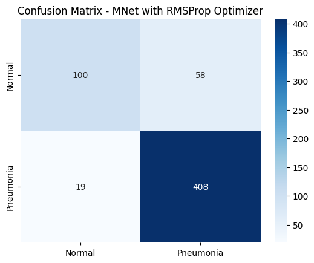

```python
y_pred_mnet_rms = mobilenet_model.predict(test_images)
y_pred_mnet_rms = (y_pred_mnet_rms > 0.5).astype("int32")

mnet_rms_cm = confusion_matrix(test_labels, y_pred_mnet_rms)
print("MNet Classification Report with RMSProp Optimizer:")
print(classification_report(test_labels, y_pred_mnet_rms))

# Plot confusion matrix
sns.heatmap(mnet_rms_cm, annot=True, fmt="d", cmap='Blues', xticklabels=['Normal', 'Pneumonia'], yticklabels=['Normal', 'Pneumonia'])
plt.title("Confusion Matrix - MNet with RMSProp Optimizer")
plt.show()
```

```
19/19 ━━━━━━━━━━━━━━━━━━━━ 5s 247ms/step
```

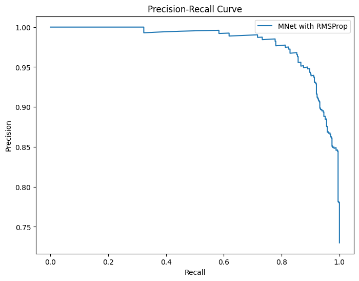

```python
precision_mnet_rms, recall_mnet_rms, _ = precision_recall_curve(test_labels, mobilenet_model.predict(test_images))

plt.figure(figsize=(8,6))
plt.plot(recall_mnet_rms, precision_mnet_rms, label='MNet with RMSProp')
plt.xlabel('Recall')
plt.ylabel('Precision')
plt.title('Precision-Recall Curve')
plt.legend()
plt.show()
```

We are going to try to fine tune the model even more, also, MobileNet is trained on input of 224 x 224 but we are using 512 x 512. We can reduce the input size to 224 x 224 and see how it affects the model.

We'll also use class weights because of the dataset imbalance

```python
train_dataset_new = image_dataset_from_directory(
    train_dir,
    image_size=(224, 224),
    batch_size=32)
validation_dataset_new = image_dataset_from_directory(
    val_dir,
    image_size=(224, 224),
    batch_size=32)
test_dataset_new = image_dataset_from_directory(
    test_dir,
    image_size=(224, 224),
    batch_size=32)
```

```
Found 4100 files belonging to 2 classes.
Found 1171 files belonging to 2 classes.
Found 585 files belonging to 2 classes.
```

```python
train_labels_new = get_labels(train_dataset_new)
val_labels_new = get_labels(validation_dataset_new)
test_labels_new = get_labels(test_dataset_new)

train_new, train_count_new = np.unique(train_labels_new, return_counts=True)
val_new, val_count_new = np.unique(val_labels_new, return_counts=True)
test_new, test_count_new = np.unique(test_labels_new, return_counts=True)


# Print the distribution
for label, count in zip(train_new, train_count_new):
    label = "Normal" if label == 0 else "Pneumonia"
    print(f"Train Class {label}: {count} images ({count/len(train_labels_new):.2%})")
for label, count in zip(val_new, val_count_new):
    label =  "Normal" if label == 0 else "Pneumonia"
    print(f"Validation Class {label}: {count} images ({count/len(val_labels_new):.2%})")
for label, count in zip(test_new, test_count_new):
    label =  "Normal" if label == 0 else "Pneumonia"
    print(f"Test Class {label}: {count} images ({count/len(test_labels_new):.2%})")
```

```
Train Class Normal: 1109 images (27.05%)
Train Class Pneumonia: 2991 images (72.95%)
Validation Class Normal: 316 images (26.99%)
Validation Class Pneumonia: 855 images (73.01%)
Test Class Normal: 158 images (27.01%)
Test Class Pneumonia: 427 images (72.99%)
```

```python
for train_data_batch_new, train_labels_batch_new in train_dataset_new:
    print ('Training Data Shape:')
    print("data batch shape:", train_data_batch_new.shape)
    print("labels batch shape:", train_labels_batch_new.shape)
    break

for val_data_batch_new, val_labels_batch_new in validation_dataset_new:
    print ('\nValidation Data Shape:')
    print("data batch shape:", val_data_batch_new.shape)
    print("labels batch shape:", val_labels_batch_new.shape)
    break

for test_data_batch_new, test_labels_batch_new in test_dataset_new:
    print ('\nTesting Data Shape:')
    print("data batch shape:", test_data_batch_new.shape)
    print("labels batch shape:", test_labels_batch_new.shape)
    break
```

```
Training Data Shape:
data batch shape: (32, 224, 224, 3)
labels batch shape: (32,)

Validation Data Shape:
data batch shape: (32, 224, 224, 3)
labels batch shape: (32,)

Testing Data Shape:
data batch shape: (32, 224, 224, 3)
labels batch shape: (32,)
```

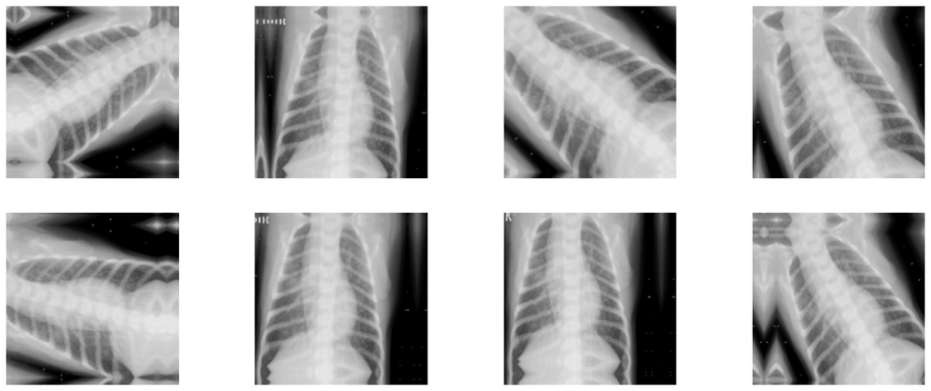

```python
plt.figure(figsize=(20, 8))
for images, _ in train_dataset_new.take(1):
    for i in range(8):
        augmented_images_new = data_augmentation_layer(images)
        ax = plt.subplot(2, 4, i + 1)
        plt.imshow(augmented_images_new[0].numpy().astype("uint8"))
        plt.axis("off")
```

```python
# Loading the MobileNet model
mnet_base2 =  MobileNetV2(
    weights="imagenet",
    include_top=False,
    input_shape=(224, 224, 3))

mnet_base2.trainable = False
```

```python
def get_features_and_labels(dataset):
    all_features = []
    all_labels = []
    for images, labels in dataset:
        preprocessed_images = preprocess_input(images)
        features = mnet_base2.predict(preprocessed_images)
        all_features.append(features)
        all_labels.append(labels)
    return np.concatenate(all_features), np.concatenate(all_labels)

train_features_new, train_labels_new =  get_features_and_labels(train_dataset_new)
val_features_new, val_labels_new =  get_features_and_labels(validation_dataset_new)
test_features_new, test_labels_new =  get_features_and_labels(test_dataset_new)
```

```
WARNING: All log messages before absl::InitializeLog() is called are written to STDERR
I0000 00:00:1744574067.194449      71 service.cc:148] XLA service 0x7b59444b4e30 initialized for platform CUDA (this does not guarantee that XLA will be used). Devices:
I0000 00:00:1744574067.195055      71 service.cc:156]   StreamExecutor device (0): Tesla T4, Compute Capability 7.5
I0000 00:00:1744574067.195077      71 service.cc:156]   StreamExecutor device (1): Tesla T4, Compute Capability 7.5
```

```
1/1 ━━━━━━━━━━━━━━━━━━━━ 5s 5s/step
1/1 ━━━━━━━━━━━━━━━━━━━━ 0s 49ms/step
```

```
I0000 00:00:1744574070.721143      71 device_compiler.h:188] Compiled cluster using XLA!  This line is logged at most once for the lifetime of the process.
```

[output not shown]

[output cut: 128 more lines]

[output not shown]

```python
train_features_new.shape
```

```
(4100, 7, 7, 1280)
```

```python
mnet_base2.summary()
```

```
Model: "mobilenetv2_1.00_224"
```

```
┏━━━━━━━━━━━━━━━━━━━━━━━━━━━┳━━━━━━━━━━━━━━━━━━━━━━━━┳━━━━━━━━━━━━━━━━┳━━━━━━━━━━━━━━━━━━━━━━━━┓
┃ Layer (type)              ┃ Output Shape           ┃        Param # ┃ Connected to           ┃
┡━━━━━━━━━━━━━━━━━━━━━━━━━━━╇━━━━━━━━━━━━━━━━━━━━━━━━╇━━━━━━━━━━━━━━━━╇━━━━━━━━━━━━━━━━━━━━━━━━┩
│ input_layer_3             │ (None, 224, 224, 3)    │              0 │ -                      │
│ (InputLayer)              │                        │                │                        │
├───────────────────────────┼────────────────────────┼────────────────┼────────────────────────┤
│ Conv1 (Conv2D)            │ (None, 112, 112, 32)   │            864 │ input_layer_3[0][0]    │
├───────────────────────────┼────────────────────────┼────────────────┼────────────────────────┤
│ bn_Conv1                  │ (None, 112, 112, 32)   │            128 │ Conv1[0][0]            │
│ (BatchNormalization)      │                        │                │                        │
├───────────────────────────┼────────────────────────┼────────────────┼────────────────────────┤
│ Conv1_relu (ReLU)         │ (None, 112, 112, 32)   │              0 │ bn_Conv1[0][0]         │
├───────────────────────────┼────────────────────────┼────────────────┼────────────────────────┤
│ expanded_conv_depthwise   │ (None, 112, 112, 32)   │            288 │ Conv1_relu[0][0]       │
│ (DepthwiseConv2D)         │                        │                │                        │
├───────────────────────────┼────────────────────────┼────────────────┼────────────────────────┤
│ expanded_conv_depthwise_… │ (None, 112, 112, 32)   │            128 │ expanded_conv_depthwi… │
│ (BatchNormalization)      │                        │                │                        │
├───────────────────────────┼────────────────────────┼────────────────┼────────────────────────┤
│ expanded_conv_depthwise_… │ (None, 112, 112, 32)   │              0 │ expanded_conv_depthwi… │
│ (ReLU)                    │                        │                │                        │
├───────────────────────────┼────────────────────────┼────────────────┼────────────────────────┤
│ expanded_conv_project     │ (None, 112, 112, 16)   │            512 │ expanded_conv_depthwi… │
│ (Conv2D)                  │                        │                │                        │
├───────────────────────────┼────────────────────────┼────────────────┼────────────────────────┤
│ expanded_conv_project_BN  │ (None, 112, 112, 16)   │             64 │ expanded_conv_project… │
│ (BatchNormalization)      │                        │                │                        │
├───────────────────────────┼────────────────────────┼────────────────┼────────────────────────┤
│ block_1_expand (Conv2D)   │ (None, 112, 112, 96)   │          1,536 │ expanded_conv_project… │
├───────────────────────────┼────────────────────────┼────────────────┼────────────────────────┤
│ block_1_expand_BN         │ (None, 112, 112, 96)   │            384 │ block_1_expand[0][0]   │
│ (BatchNormalization)      │                        │                │                        │
├───────────────────────────┼────────────────────────┼────────────────┼────────────────────────┤
│ block_1_expand_relu       │ (None, 112, 112, 96)   │              0 │ block_1_expand_BN[0][… │
│ (ReLU)                    │                        │                │                        │
├───────────────────────────┼────────────────────────┼────────────────┼────────────────────────┤
│ block_1_pad               │ (None, 113, 113, 96)   │              0 │ block_1_expand_relu[0… │
│ (ZeroPadding2D)           │                        │                │                        │
├───────────────────────────┼────────────────────────┼────────────────┼────────────────────────┤
│ block_1_depthwise         │ (None, 56, 56, 96)     │            864 │ block_1_pad[0][0]      │
```

[output cut: 374 more lines]

```
│ block_16_depthwise_relu   │ (None, 7, 7, 960)      │              0 │ block_16_depthwise_BN… │
│ (ReLU)                    │                        │                │                        │
├───────────────────────────┼────────────────────────┼────────────────┼────────────────────────┤
│ block_16_project (Conv2D) │ (None, 7, 7, 320)      │        307,200 │ block_16_depthwise_re… │
├───────────────────────────┼────────────────────────┼────────────────┼────────────────────────┤
│ block_16_project_BN       │ (None, 7, 7, 320)      │          1,280 │ block_16_project[0][0] │
│ (BatchNormalization)      │                        │                │                        │
├───────────────────────────┼────────────────────────┼────────────────┼────────────────────────┤
│ Conv_1 (Conv2D)           │ (None, 7, 7, 1280)     │        409,600 │ block_16_project_BN[0… │
├───────────────────────────┼────────────────────────┼────────────────┼────────────────────────┤
│ Conv_1_bn                 │ (None, 7, 7, 1280)     │          5,120 │ Conv_1[0][0]           │
│ (BatchNormalization)      │                        │                │                        │
├───────────────────────────┼────────────────────────┼────────────────┼────────────────────────┤
│ out_relu (ReLU)           │ (None, 7, 7, 1280)     │              0 │ Conv_1_bn[0][0]        │
└───────────────────────────┴────────────────────────┴────────────────┴────────────────────────┘
```

```
 Total params: 2,257,984 (8.61 MB)
```

```
 Trainable params: 0 (0.00 B)
```

```
 Non-trainable params: 2,257,984 (8.61 MB)
```

```python
mnet_base2.trainable = True

# Only fine-tune the top layers of MobileNet
for layer in mnet_base2.layers[:100]:
    layer.trainable = False
```

```python
mnet_base2.summary()
```

```
Model: "mobilenetv2_1.00_224"
```

```
┏━━━━━━━━━━━━━━━━━━━━━━━━━━━┳━━━━━━━━━━━━━━━━━━━━━━━━┳━━━━━━━━━━━━━━━━┳━━━━━━━━━━━━━━━━━━━━━━━━┓
┃ Layer (type)              ┃ Output Shape           ┃        Param # ┃ Connected to           ┃
┡━━━━━━━━━━━━━━━━━━━━━━━━━━━╇━━━━━━━━━━━━━━━━━━━━━━━━╇━━━━━━━━━━━━━━━━╇━━━━━━━━━━━━━━━━━━━━━━━━┩
│ input_layer_3             │ (None, 224, 224, 3)    │              0 │ -                      │
│ (InputLayer)              │                        │                │                        │
├───────────────────────────┼────────────────────────┼────────────────┼────────────────────────┤
│ Conv1 (Conv2D)            │ (None, 112, 112, 32)   │            864 │ input_layer_3[0][0]    │
├───────────────────────────┼────────────────────────┼────────────────┼────────────────────────┤
│ bn_Conv1                  │ (None, 112, 112, 32)   │            128 │ Conv1[0][0]            │
│ (BatchNormalization)      │                        │                │                        │
├───────────────────────────┼────────────────────────┼────────────────┼────────────────────────┤
│ Conv1_relu (ReLU)         │ (None, 112, 112, 32)   │              0 │ bn_Conv1[0][0]         │
├───────────────────────────┼────────────────────────┼────────────────┼────────────────────────┤
│ expanded_conv_depthwise   │ (None, 112, 112, 32)   │            288 │ Conv1_relu[0][0]       │
│ (DepthwiseConv2D)         │                        │                │                        │
├───────────────────────────┼────────────────────────┼────────────────┼────────────────────────┤
│ expanded_conv_depthwise_… │ (None, 112, 112, 32)   │            128 │ expanded_conv_depthwi… │
│ (BatchNormalization)      │                        │                │                        │
├───────────────────────────┼────────────────────────┼────────────────┼────────────────────────┤
│ expanded_conv_depthwise_… │ (None, 112, 112, 32)   │              0 │ expanded_conv_depthwi… │
│ (ReLU)                    │                        │                │                        │
├───────────────────────────┼────────────────────────┼────────────────┼────────────────────────┤
│ expanded_conv_project     │ (None, 112, 112, 16)   │            512 │ expanded_conv_depthwi… │
│ (Conv2D)                  │                        │                │                        │
├───────────────────────────┼────────────────────────┼────────────────┼────────────────────────┤
│ expanded_conv_project_BN  │ (None, 112, 112, 16)   │             64 │ expanded_conv_project… │
│ (BatchNormalization)      │                        │                │                        │
├───────────────────────────┼────────────────────────┼────────────────┼────────────────────────┤
│ block_1_expand (Conv2D)   │ (None, 112, 112, 96)   │          1,536 │ expanded_conv_project… │
├───────────────────────────┼────────────────────────┼────────────────┼────────────────────────┤
│ block_1_expand_BN         │ (None, 112, 112, 96)   │            384 │ block_1_expand[0][0]   │
│ (BatchNormalization)      │                        │                │                        │
├───────────────────────────┼────────────────────────┼────────────────┼────────────────────────┤
│ block_1_expand_relu       │ (None, 112, 112, 96)   │              0 │ block_1_expand_BN[0][… │
│ (ReLU)                    │                        │                │                        │
├───────────────────────────┼────────────────────────┼────────────────┼────────────────────────┤
│ block_1_pad               │ (None, 113, 113, 96)   │              0 │ block_1_expand_relu[0… │
│ (ZeroPadding2D)           │                        │                │                        │
├───────────────────────────┼────────────────────────┼────────────────┼────────────────────────┤
│ block_1_depthwise         │ (None, 56, 56, 96)     │            864 │ block_1_pad[0][0]      │
```

[output cut: 374 more lines]

```
│ block_16_depthwise_relu   │ (None, 7, 7, 960)      │              0 │ block_16_depthwise_BN… │
│ (ReLU)                    │                        │                │                        │
├───────────────────────────┼────────────────────────┼────────────────┼────────────────────────┤
│ block_16_project (Conv2D) │ (None, 7, 7, 320)      │        307,200 │ block_16_depthwise_re… │
├───────────────────────────┼────────────────────────┼────────────────┼────────────────────────┤
│ block_16_project_BN       │ (None, 7, 7, 320)      │          1,280 │ block_16_project[0][0] │
│ (BatchNormalization)      │                        │                │                        │
├───────────────────────────┼────────────────────────┼────────────────┼────────────────────────┤
│ Conv_1 (Conv2D)           │ (None, 7, 7, 1280)     │        409,600 │ block_16_project_BN[0… │
├───────────────────────────┼────────────────────────┼────────────────┼────────────────────────┤
│ Conv_1_bn                 │ (None, 7, 7, 1280)     │          5,120 │ Conv_1[0][0]           │
│ (BatchNormalization)      │                        │                │                        │
├───────────────────────────┼────────────────────────┼────────────────┼────────────────────────┤
│ out_relu (ReLU)           │ (None, 7, 7, 1280)     │              0 │ Conv_1_bn[0][0]        │
└───────────────────────────┴────────────────────────┴────────────────┴────────────────────────┘
```

```
 Total params: 2,257,984 (8.61 MB)
```

```
 Trainable params: 1,861,440 (7.10 MB)
```

```
 Non-trainable params: 396,544 (1.51 MB)
```

```python
# Define the augmentation layer
data_augmentation_layer_new = keras.Sequential(
    [
        keras.layers.RandomRotation(0.2),
        keras.layers.RandomZoom(0.2),
        keras.layers.RandomTranslation(0.1, 0.1),
        keras.layers.RandomContrast(0.1),
    ]
)
```

```python
inputs = keras.Input(shape=(224, 224, 3))
x = data_augmentation_layer_new(inputs)
x = preprocess_input(x)
x = mnet_base2(x)
x = layers.GlobalAveragePooling2D()(x)
x = layers.Dropout(0.2)(x)
x = layers.Dense(units = 128 , activation = 'sigmoid')(x)
outputs = layers.Dense(units = 1 , activation = 'sigmoid')(x)
mnet_model = keras.Model(inputs, outputs)
```

```python
mnet_model.summary()
```

```
Model: "functional_3"
```

```
┏━━━━━━━━━━━━━━━━━━━━━━━━━━━━━━━━━━━━━━┳━━━━━━━━━━━━━━━━━━━━━━━━━━━━━┳━━━━━━━━━━━━━━━━━┓
┃ Layer (type)                         ┃ Output Shape                ┃         Param # ┃
┡━━━━━━━━━━━━━━━━━━━━━━━━━━━━━━━━━━━━━━╇━━━━━━━━━━━━━━━━━━━━━━━━━━━━━╇━━━━━━━━━━━━━━━━━┩
│ input_layer_5 (InputLayer)           │ (None, 224, 224, 3)         │               0 │
├──────────────────────────────────────┼─────────────────────────────┼─────────────────┤
│ sequential_1 (Sequential)            │ (None, 224, 224, 3)         │               0 │
├──────────────────────────────────────┼─────────────────────────────┼─────────────────┤
│ true_divide (TrueDivide)             │ (None, 224, 224, 3)         │               0 │
├──────────────────────────────────────┼─────────────────────────────┼─────────────────┤
│ subtract (Subtract)                  │ (None, 224, 224, 3)         │               0 │
├──────────────────────────────────────┼─────────────────────────────┼─────────────────┤
│ mobilenetv2_1.00_224 (Functional)    │ (None, 7, 7, 1280)          │       2,257,984 │
├──────────────────────────────────────┼─────────────────────────────┼─────────────────┤
│ global_average_pooling2d_1           │ (None, 1280)                │               0 │
│ (GlobalAveragePooling2D)             │                             │                 │
├──────────────────────────────────────┼─────────────────────────────┼─────────────────┤
│ dropout_1 (Dropout)                  │ (None, 1280)                │               0 │
├──────────────────────────────────────┼─────────────────────────────┼─────────────────┤
│ dense_2 (Dense)                      │ (None, 128)                 │         163,968 │
├──────────────────────────────────────┼─────────────────────────────┼─────────────────┤
│ dense_3 (Dense)                      │ (None, 1)                   │             129 │
└──────────────────────────────────────┴─────────────────────────────┴─────────────────┘
```

```
 Total params: 2,422,081 (9.24 MB)
```

```
 Trainable params: 2,025,537 (7.73 MB)
```

```
 Non-trainable params: 396,544 (1.51 MB)
```

```python
class_weights = class_weight.compute_class_weight(
    class_weight='balanced',
    classes=np.unique(train_labels_new),
    y=train_labels_new
)
```

```python
mnet_model.compile(
    loss="binary_crossentropy",
    optimizer="adam",
    metrics=["accuracy"]
)

callbacks = [
    keras.callbacks.ModelCheckpoint(
        filepath="/kaggle/working/best_mnet_adam.keras",
        save_best_only=True,
        monitor="val_loss"
    ),

    # Early stopping to prevent overfitting
    EarlyStopping(
        monitor='val_loss',
        patience=10,               # Stop if no improvement for 10 epochs
        restore_best_weights=True  # Restore model to the best epoch
    ),

    # Learning rate reduction when plateauing
    ReduceLROnPlateau(
        monitor='val_loss',
        factor=0.5,                # Reduce LR by half
        patience=3,                # Wait 5 epochs before reducing
        min_lr=1e-6                # Don't go below this LR
    )
]

history = mnet_model.fit(
    train_dataset_new,
    epochs=50,
    class_weight={0: class_weights[0], 1: class_weights[1]},
    validation_data=validation_dataset_new,
    callbacks=callbacks
)
```

```
129/129 ━━━━━━━━━━━━━━━━━━━━ 41s 156ms/step - accuracy: 0.8805 - loss: 0.2944 - val_accuracy: 0.7301 - val_loss: 1.9868 - learning_rate: 0.0010
129/129 ━━━━━━━━━━━━━━━━━━━━ 17s 134ms/step - accuracy: 0.9347 - loss: 0.1861 - val_accuracy: 0.7301 - val_loss: 1.9672 - learning_rate: 0.0010
129/129 ━━━━━━━━━━━━━━━━━━━━ 17s 131ms/step - accuracy: 0.9511 - loss: 0.1362 - val_accuracy: 0.9009 - val_loss: 0.4144 - learning_rate: 0.0010
129/129 ━━━━━━━━━━━━━━━━━━━━ 17s 129ms/step - accuracy: 0.9631 - loss: 0.1198 - val_accuracy: 0.8958 - val_loss: 0.5657 - learning_rate: 0.0010
129/129 ━━━━━━━━━━━━━━━━━━━━ 17s 129ms/step - accuracy: 0.9596 - loss: 0.1019 - val_accuracy: 0.8839 - val_loss: 0.3408 - learning_rate: 0.0010
129/129 ━━━━━━━━━━━━━━━━━━━━ 17s 129ms/step - accuracy: 0.9623 - loss: 0.1011 - val_accuracy: 0.5858 - val_loss: 1.5335 - learning_rate: 0.0010
129/129 ━━━━━━━━━━━━━━━━━━━━ 17s 130ms/step - accuracy: 0.9712 - loss: 0.0801 - val_accuracy: 0.9120 - val_loss: 0.2597 - learning_rate: 0.0010
129/129 ━━━━━━━━━━━━━━━━━━━━ 17s 128ms/step - accuracy: 0.9706 - loss: 0.0838 - val_accuracy: 0.4757 - val_loss: 2.0796 - learning_rate: 0.0010
129/129 ━━━━━━━━━━━━━━━━━━━━ 17s 130ms/step - accuracy: 0.9750 - loss: 0.0723 - val_accuracy: 0.9360 - val_loss: 0.2188 - learning_rate: 0.0010
129/129 ━━━━━━━━━━━━━━━━━━━━ 17s 128ms/step - accuracy: 0.9561 - loss: 0.1092 - val_accuracy: 0.8864 - val_loss: 0.4159 - learning_rate: 0.0010
129/129 ━━━━━━━━━━━━━━━━━━━━ 16s 125ms/step - accuracy: 0.9707 - loss: 0.0874 - val_accuracy: 0.5278 - val_loss: 2.0636 - learning_rate: 0.0010
129/129 ━━━━━━━━━━━━━━━━━━━━ 17s 129ms/step - accuracy: 0.9744 - loss: 0.0720 - val_accuracy: 0.2895 - val_loss: 3.5813 - learning_rate: 0.0010
129/129 ━━━━━━━━━━━━━━━━━━━━ 16s 126ms/step - accuracy: 0.9823 - loss: 0.0521 - val_accuracy: 0.4671 - val_loss: 2.4024 - learning_rate: 5.0000e-04
129/129 ━━━━━━━━━━━━━━━━━━━━ 17s 129ms/step - accuracy: 0.9853 - loss: 0.0439 - val_accuracy: 0.7088 - val_loss: 1.3166 - learning_rate: 5.0000e-04
129/129 ━━━━━━━━━━━━━━━━━━━━ 16s 125ms/step - accuracy: 0.9794 - loss: 0.0507 - val_accuracy: 0.8702 - val_loss: 0.5771 - learning_rate: 5.0000e-04
129/129 ━━━━━━━━━━━━━━━━━━━━ 17s 133ms/step - accuracy: 0.9843 - loss: 0.0385 - val_accuracy: 0.9488 - val_loss: 0.2021 - learning_rate: 2.5000e-04
129/129 ━━━━━━━━━━━━━━━━━━━━ 16s 125ms/step - accuracy: 0.9849 - loss: 0.0454 - val_accuracy: 0.8873 - val_loss: 0.4463 - learning_rate: 2.5000e-04
129/129 ━━━━━━━━━━━━━━━━━━━━ 17s 130ms/step - accuracy: 0.9888 - loss: 0.0334 - val_accuracy: 0.9556 - val_loss: 0.2032 - learning_rate: 2.5000e-04
129/129 ━━━━━━━━━━━━━━━━━━━━ 16s 126ms/step - accuracy: 0.9868 - loss: 0.0393 - val_accuracy: 0.9496 - val_loss: 0.2039 - learning_rate: 2.5000e-04
129/129 ━━━━━━━━━━━━━━━━━━━━ 21s 132ms/step - accuracy: 0.9894 - loss: 0.0295 - val_accuracy: 0.9582 - val_loss: 0.1675 - learning_rate: 1.2500e-04
129/129 ━━━━━━━━━━━━━━━━━━━━ 17s 134ms/step - accuracy: 0.9864 - loss: 0.0356 - val_accuracy: 0.9590 - val_loss: 0.1593 - learning_rate: 1.2500e-04
129/129 ━━━━━━━━━━━━━━━━━━━━ 16s 126ms/step - accuracy: 0.9901 - loss: 0.0252 - val_accuracy: 0.9539 - val_loss: 0.1753 - learning_rate: 1.2500e-04
129/129 ━━━━━━━━━━━━━━━━━━━━ 17s 133ms/step - accuracy: 0.9905 - loss: 0.0216 - val_accuracy: 0.9684 - val_loss: 0.1358 - learning_rate: 1.2500e-04
129/129 ━━━━━━━━━━━━━━━━━━━━ 16s 126ms/step - accuracy: 0.9882 - loss: 0.0306 - val_accuracy: 0.9616 - val_loss: 0.1581 - learning_rate: 1.2500e-04
129/129 ━━━━━━━━━━━━━━━━━━━━ 17s 129ms/step - accuracy: 0.9917 - loss: 0.0245 - val_accuracy: 0.9496 - val_loss: 0.1904 - learning_rate: 1.2500e-04
129/129 ━━━━━━━━━━━━━━━━━━━━ 16s 127ms/step - accuracy: 0.9893 - loss: 0.0271 - val_accuracy: 0.9513 - val_loss: 0.1921 - learning_rate: 1.2500e-04
129/129 ━━━━━━━━━━━━━━━━━━━━ 17s 129ms/step - accuracy: 0.9924 - loss: 0.0200 - val_accuracy: 0.9573 - val_loss: 0.1635 - learning_rate: 6.2500e-05
129/129 ━━━━━━━━━━━━━━━━━━━━ 16s 125ms/step - accuracy: 0.9936 - loss: 0.0184 - val_accuracy: 0.9624 - val_loss: 0.1444 - learning_rate: 6.2500e-05
129/129 ━━━━━━━━━━━━━━━━━━━━ 17s 133ms/step - accuracy: 0.9927 - loss: 0.0177 - val_accuracy: 0.9658 - val_loss: 0.1321 - learning_rate: 6.2500e-05
129/129 ━━━━━━━━━━━━━━━━━━━━ 16s 125ms/step - accuracy: 0.9952 - loss: 0.0137 - val_accuracy: 0.9641 - val_loss: 0.1398 - learning_rate: 6.2500e-05
129/129 ━━━━━━━━━━━━━━━━━━━━ 17s 129ms/step - accuracy: 0.9922 - loss: 0.0176 - val_accuracy: 0.9650 - val_loss: 0.1323 - learning_rate: 6.2500e-05
129/129 ━━━━━━━━━━━━━━━━━━━━ 16s 126ms/step - accuracy: 0.9925 - loss: 0.0207 - val_accuracy: 0.9633 - val_loss: 0.1397 - learning_rate: 6.2500e-05
129/129 ━━━━━━━━━━━━━━━━━━━━ 19s 149ms/step - accuracy: 0.9962 - loss: 0.0128 - val_accuracy: 0.9684 - val_loss: 0.1317 - learning_rate: 3.1250e-05
```

[output cut: 17 more lines]

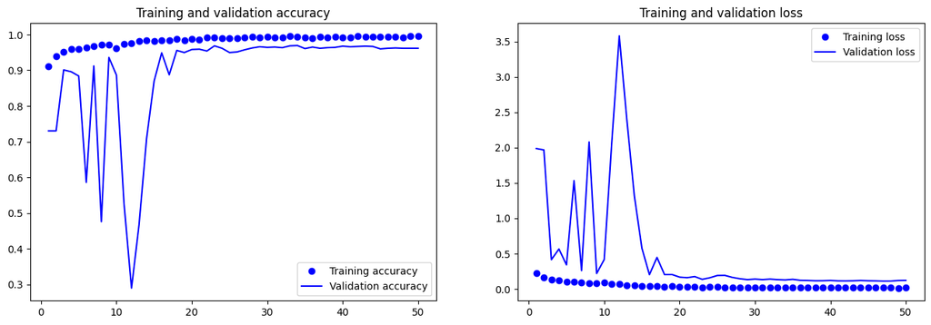

```python
train_accuracy_mnet_adam = history.history["accuracy"]
val_accuracy_mnet_adam = history.history["val_accuracy"]
train_loss_mnet_adam = history.history["loss"]
val_loss_mnet_adam = history.history["val_loss"]

fig, axes = plt.subplots(1, 2, figsize=(16, 5))
axes = axes.ravel()

epochs = range(1, len(train_accuracy_mnet_adam) + 1)
axes[0].plot(epochs, train_accuracy_mnet_adam, "bo", label="Training accuracy")
axes[0].plot(epochs, val_accuracy_mnet_adam, "b", label="Validation accuracy")
axes[0].set_title("Training and validation accuracy")
axes[0].legend()
axes[1].plot(epochs, train_loss_mnet_adam, "bo", label="Training loss")
axes[1].plot(epochs, val_loss_mnet_adam, "b", label="Validation loss")
axes[1].set_title("Training and validation loss")
axes[1].legend()
plt.show()
```

```python
# Load the best models (the best ones saved during training)
mnet_model.load_weights("/kaggle/working/best_mnet_adam.keras")
```

```python
mnet_adam_model_loss, mnet_adam_model_acc = mnet_model.evaluate(test_dataset_new)

print(f"MobileNet Accuracy (Adam): {mnet_adam_model_acc}")
```

```
19/19 ━━━━━━━━━━━━━━━━━━━━ 1s 61ms/step - accuracy: 0.8965 - loss: 0.3567
MobileNet Accuracy (Adam): 0.8957265019416809
```

```python
# --- Convert test dataset to NumPy arrays ---
test_images_list_new = []
test_labels_list_new = []

for images, labels in test_dataset_new:
    test_images_list_new.append(images.numpy())
    test_labels_list_new.append(labels.numpy())

test_images_new = np.concatenate(test_images_list_new)
test_labels_new = np.concatenate(test_labels_list_new)
```

```
19/19 ━━━━━━━━━━━━━━━━━━━━ 4s 125ms/step
MNet Classification Report with Adam Optimizer:
              precision    recall  f1-score   support

           0       0.96      0.64      0.77       158
           1       0.88      0.99      0.93       427

    accuracy                           0.90       585
   macro avg       0.92      0.81      0.85       585
weighted avg       0.90      0.90      0.89       585
```

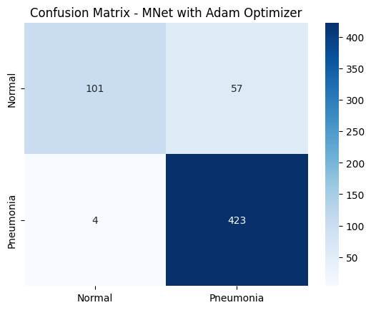

```python
y_pred_mnet_adam = mnet_model.predict(test_images_new)
y_pred_mnet_adam = (y_pred_mnet_adam > 0.5).astype("int32")

mnet_adam_cm = confusion_matrix(test_labels_new, y_pred_mnet_adam)
print("MNet Classification Report with Adam Optimizer:")
print(classification_report(test_labels_new, y_pred_mnet_adam))

# Plot confusion matrix
sns.heatmap(mnet_adam_cm, annot=True, fmt="d", cmap='Blues', xticklabels=['Normal', 'Pneumonia'], yticklabels=['Normal', 'Pneumonia'])
plt.title("Confusion Matrix - MNet with Adam Optimizer")
plt.show()
```

```
19/19 ━━━━━━━━━━━━━━━━━━━━ 1s 49ms/step
```

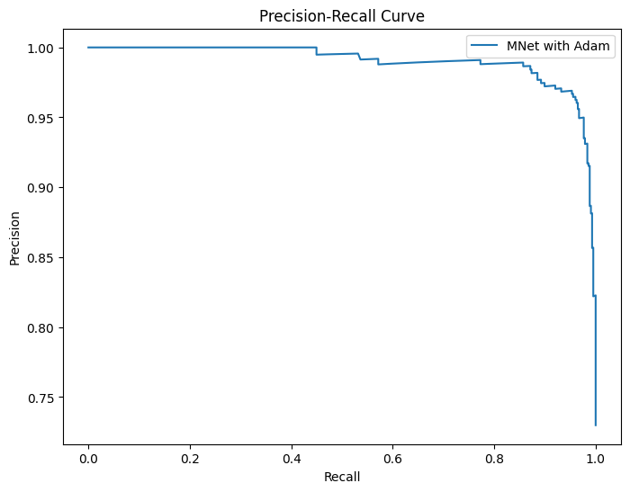

```python
precision_mnet_adam, recall_mnet_adam, _ = precision_recall_curve(test_labels_new, mnet_model.predict(test_images_new))

plt.figure(figsize=(8,6))
plt.plot(recall_mnet_adam, precision_mnet_adam, label='MNet with Adam')
plt.xlabel('Recall')
plt.ylabel('Precision')
plt.title('Precision-Recall Curve')
plt.legend()
plt.show()
```